# Data manipulation and plotting

## Setup

Cheatsheets for dplyr and ggplot2 are available in rstudio by using the Help menu (Help -> Cheatsheets)

Install and load the libraries

```r
# if libraries are not installed uncomment the next 3 lines
# install.packages('dplyr')
# install.packages('ggplot2')
# install.packages('tidyr')

library(dplyr)
library(ggplot2)
library(tidyr)
```

## Data manipulation using dplyr

Have a look at the iris dataset and introduce %>% for piping

Most commands will end with a ‘%>% head()’ to reduce excessive results being displayed

```r
data("iris")
View(iris)

iris %>% head()
```

```
##   Sepal.Length Sepal.Width Petal.Length Petal.Width Species
## 1          5.1         3.5          1.4         0.2  setosa
## 2          4.9         3.0          1.4         0.2  setosa
## 3          4.7         3.2          1.3         0.2  setosa
## 4          4.6         3.1          1.5         0.2  setosa
## 5          5.0         3.6          1.4         0.2  setosa
## 6          5.4         3.9          1.7         0.4  setosa
```

```r
head(iris)
```

```
##   Sepal.Length Sepal.Width Petal.Length Petal.Width Species
## 1          5.1         3.5          1.4         0.2  setosa
## 2          4.9         3.0          1.4         0.2  setosa
## 3          4.7         3.2          1.3         0.2  setosa
## 4          4.6         3.1          1.5         0.2  setosa
## 5          5.0         3.6          1.4         0.2  setosa
## 6          5.4         3.9          1.7         0.4  setosa
```

```r
names(iris)
```

```
## [1] "Sepal.Length" "Sepal.Width"  "Petal.Length" "Petal.Width"
## [5] "Species"
```

```r
colnames(iris)
```

```
## [1] "Sepal.Length" "Sepal.Width"  "Petal.Length" "Petal.Width"
## [5] "Species"
```

Demonstrate standard versus dplyr method for selecting a column

```r
iris[,"Sepal.Length"]
```

```
##   [1] 5.1 4.9 4.7 4.6 5.0 5.4 4.6 5.0 4.4 4.9 5.4 4.8 4.8 4.3 5.8 5.7 5.4
##  [18] 5.1 5.7 5.1 5.4 5.1 4.6 5.1 4.8 5.0 5.0 5.2 5.2 4.7 4.8 5.4 5.2 5.5
##  [35] 4.9 5.0 5.5 4.9 4.4 5.1 5.0 4.5 4.4 5.0 5.1 4.8 5.1 4.6 5.3 5.0 7.0
##  [52] 6.4 6.9 5.5 6.5 5.7 6.3 4.9 6.6 5.2 5.0 5.9 6.0 6.1 5.6 6.7 5.6 5.8
##  [69] 6.2 5.6 5.9 6.1 6.3 6.1 6.4 6.6 6.8 6.7 6.0 5.7 5.5 5.5 5.8 6.0 5.4
##  [86] 6.0 6.7 6.3 5.6 5.5 5.5 6.1 5.8 5.0 5.6 5.7 5.7 6.2 5.1 5.7 6.3 5.8
## [103] 7.1 6.3 6.5 7.6 4.9 7.3 6.7 7.2 6.5 6.4 6.8 5.7 5.8 6.4 6.5 7.7 7.7
## [120] 6.0 6.9 5.6 7.7 6.3 6.7 7.2 6.2 6.1 6.4 7.2 7.4 7.9 6.4 6.3 6.1 7.7
## [137] 6.3 6.4 6.0 6.9 6.7 6.9 5.8 6.8 6.7 6.7 6.3 6.5 6.2 5.9
```

```r
iris$Sepal.Length
```

```
##   [1] 5.1 4.9 4.7 4.6 5.0 5.4 4.6 5.0 4.4 4.9 5.4 4.8 4.8 4.3 5.8 5.7 5.4
##  [18] 5.1 5.7 5.1 5.4 5.1 4.6 5.1 4.8 5.0 5.0 5.2 5.2 4.7 4.8 5.4 5.2 5.5
##  [35] 4.9 5.0 5.5 4.9 4.4 5.1 5.0 4.5 4.4 5.0 5.1 4.8 5.1 4.6 5.3 5.0 7.0
##  [52] 6.4 6.9 5.5 6.5 5.7 6.3 4.9 6.6 5.2 5.0 5.9 6.0 6.1 5.6 6.7 5.6 5.8
##  [69] 6.2 5.6 5.9 6.1 6.3 6.1 6.4 6.6 6.8 6.7 6.0 5.7 5.5 5.5 5.8 6.0 5.4
##  [86] 6.0 6.7 6.3 5.6 5.5 5.5 6.1 5.8 5.0 5.6 5.7 5.7 6.2 5.1 5.7 6.3 5.8
## [103] 7.1 6.3 6.5 7.6 4.9 7.3 6.7 7.2 6.5 6.4 6.8 5.7 5.8 6.4 6.5 7.7 7.7
## [120] 6.0 6.9 5.6 7.7 6.3 6.7 7.2 6.2 6.1 6.4 7.2 7.4 7.9 6.4 6.3 6.1 7.7
## [137] 6.3 6.4 6.0 6.9 6.7 6.9 5.8 6.8 6.7 6.7 6.3 6.5 6.2 5.9
```

```r
# select 2 columns with dplyr
iris %>% select(Sepal.Length, Sepal.Width) %>% head()
```

```
##   Sepal.Length Sepal.Width
## 1          5.1         3.5
## 2          4.9         3.0
## 3          4.7         3.2
## 4          4.6         3.1
## 5          5.0         3.6
## 6          5.4         3.9
```

```r
# use -columnname to deselect that column
iris %>% select( -Species) %>% head()
```

```
##   Sepal.Length Sepal.Width Petal.Length Petal.Width
## 1          5.1         3.5          1.4         0.2
## 2          4.9         3.0          1.4         0.2
## 3          4.7         3.2          1.3         0.2
## 4          4.6         3.1          1.5         0.2
## 5          5.0         3.6          1.4         0.2
## 6          5.4         3.9          1.7         0.4
```

Choose rows using filter()

```r
iris %>% select(Sepal.Length, Sepal.Width) %>% filter(Sepal.Length > 5) %>% head()
```

```
##   Sepal.Length Sepal.Width
## 1          5.1         3.5
## 2          5.4         3.9
## 3          5.4         3.7
## 4          5.8         4.0
## 5          5.7         4.4
## 6          5.4         3.9
```

Summarise data

```r
iris %>%
  select(Sepal.Length, Sepal.Width) %>%
  filter(Sepal.Length > 5) %>%
  summarise(min(Sepal.Length), max(Sepal.Width))
```

```
##   min(Sepal.Length) max(Sepal.Width)
## 1               5.1              4.4
```

```r
iris %>%
  select(Sepal.Length, Sepal.Width) %>%
  filter(Sepal.Length > 5) %>%
  summarise(minLength = min(Sepal.Length), maxWidth = max(Sepal.Width))
```

```
##   minLength maxWidth
## 1       5.1      4.4
```

Use of group_by() to summarise by groups

```r
iris %>%
  select(Sepal.Length, Sepal.Width, Species) %>%
  filter(Sepal.Length > 5) %>%
  group_by(Species) %>%
  summarise(minLength = min(Sepal.Length), maxWidth = max(Sepal.Width))
```

```
## # A tibble: 3 × 3
##      Species minLength maxWidth
##       <fctr>     <dbl>    <dbl>
## 1     setosa       5.1      4.4
## 2 versicolor       5.1      3.4
## 3  virginica       5.6      3.8
```

tally() to count rows and compare with results from dim()

```r
iris %>%
  select(Sepal.Length, Sepal.Width, Species) %>%
  filter(Sepal.Length > 5) %>%
  tally()
```

```
##     n
## 1 118
```

```r
dim(iris[iris$Sepal.Length > 5, ])
```

```
## [1] 118   5
```

tally() on groups

```r
iris %>%
  select(Sepal.Length, Sepal.Width, Species) %>%
  filter(Sepal.Length > 5) %>%
  group_by(Species) %>%
  tally()
```

```
## # A tibble: 3 × 2
##      Species     n
##       <fctr> <int>
## 1     setosa    22
## 2 versicolor    47
## 3  virginica    49
```

creating new columns with mutate()

```r
iris %>%
  select(Sepal.Length, Sepal.Width, Species) %>%
  filter(Sepal.Length > 5) %>%
  mutate(Length100 = Sepal.Length * 100, length100_2 = Length100 * 2) %>%
  head()
```

```
##   Sepal.Length Sepal.Width Species Length100 length100_2
## 1          5.1         3.5  setosa       510        1020
## 2          5.4         3.9  setosa       540        1080
## 3          5.4         3.7  setosa       540        1080
## 4          5.8         4.0  setosa       580        1160
## 5          5.7         4.4  setosa       570        1140
## 6          5.4         3.9  setosa       540        1080
```

sorting data in ascending order based on column using arrange()

```r
iris %>%
  select(Sepal.Length, Sepal.Width, Species) %>%
  filter(Sepal.Length > 5) %>%
  arrange(Sepal.Length) %>%
  head()
```

```
##   Sepal.Length Sepal.Width Species
## 1          5.1         3.5  setosa
## 2          5.1         3.5  setosa
## 3          5.1         3.8  setosa
## 4          5.1         3.7  setosa
## 5          5.1         3.3  setosa
## 6          5.1         3.4  setosa
```

```r
# arranged in descending order using desc() inside arrange()
iris %>%
  select(Sepal.Length, Sepal.Width, Species) %>%
  filter(Sepal.Length > 5) %>%
  arrange(desc(Sepal.Length)) %>%
  head()
```

```
##   Sepal.Length Sepal.Width   Species
## 1          7.9         3.8 virginica
## 2          7.7         3.8 virginica
## 3          7.7         2.6 virginica
## 4          7.7         2.8 virginica
## 5          7.7         3.0 virginica
## 6          7.6         3.0 virginica
```

Showing the unique rows with distinct()

```r
iris %>%
  select(Sepal.Length, Species) %>%
  filter(Sepal.Length > 5) %>%
  arrange(desc(Sepal.Length)) %>%
  select(Sepal.Length, Species) %>%
  distinct() %>%
  head()
```

```
##   Sepal.Length   Species
## 1          7.9 virginica
## 2          7.7 virginica
## 3          7.6 virginica
## 4          7.4 virginica
## 5          7.3 virginica
## 6          7.2 virginica
```

```r
#tally distinct rows
iris %>%
  select(Sepal.Length, Species) %>%
  filter(Sepal.Length > 5) %>%
  arrange(desc(Sepal.Length)) %>%
  select(Sepal.Length, Species) %>%
  distinct() %>%
  tally()
```

```
##    n
## 1 46
```

```r
# tally without distinct()
iris %>%
  select(Sepal.Length, Species) %>%
  filter(Sepal.Length > 5) %>%
  arrange(desc(Sepal.Length)) %>%
  select(Sepal.Length, Species) %>%
  tally()
```

```
##     n
## 1 118
```

## ggplot2

### documentation for ggplot2: http://docs.ggplot2.org/current/

ggplot2 uses a method of mapping the data, defining the aesthetics, and finally using geometric obects to represent the data

base plot example

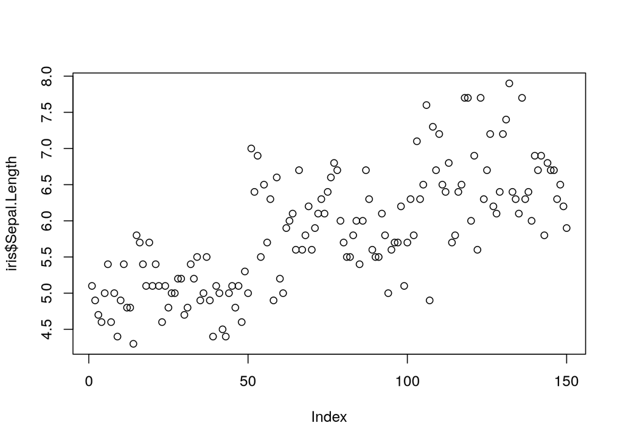

```r
plot(iris$Sepal.Length, iris$Width)
```

scatter plot

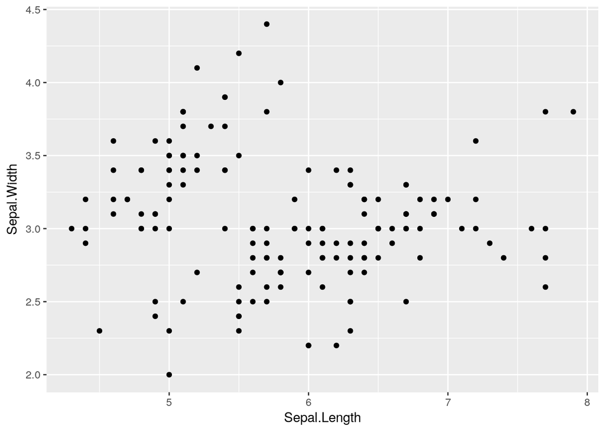

```r
ggplot(iris, aes(x = Sepal.Length, y = Sepal.Width)) + geom_point()
```

histogram

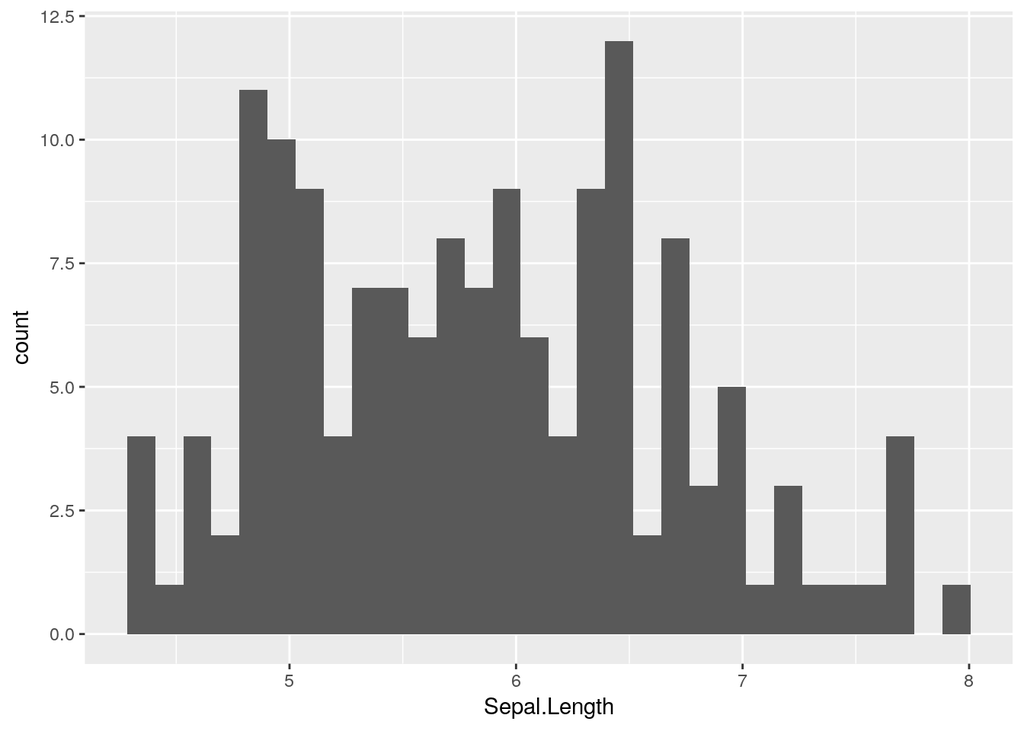

```r
ggplot(iris, aes(x = Sepal.Length)) + geom_histogram()
```

line plot

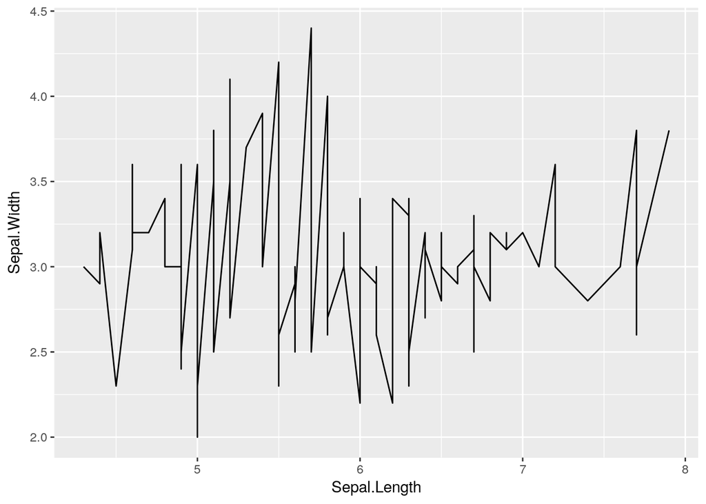

```r
ggplot(iris, aes(x = Sepal.Length, y = Sepal.Width)) + geom_line()
```

box plot

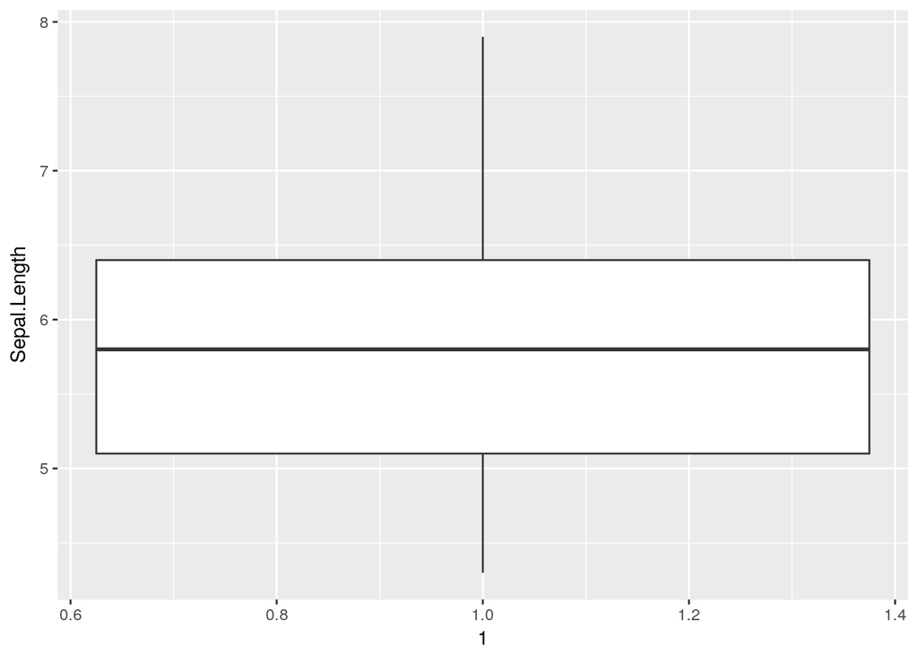

```r
# all data
ggplot(iris, aes(x = 1, y = Sepal.Length)) + geom_boxplot()
```

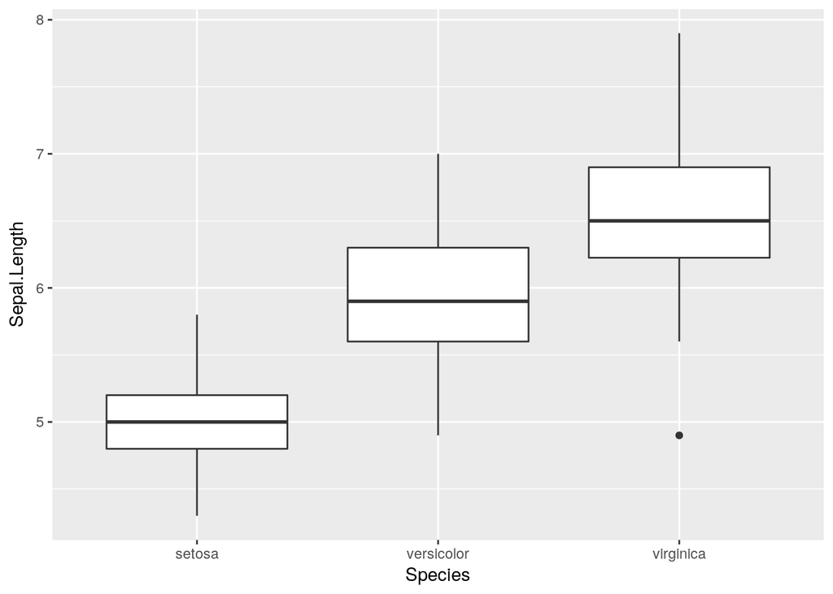

```r
# separate boxes for each species
ggplot(iris, aes(x = Species, y = Sepal.Length)) + geom_boxplot()
```

Demonstrated in this command - plot being saved as a object - multiple geoms being used - changing plot and axis titles - changing colours - using a different theme

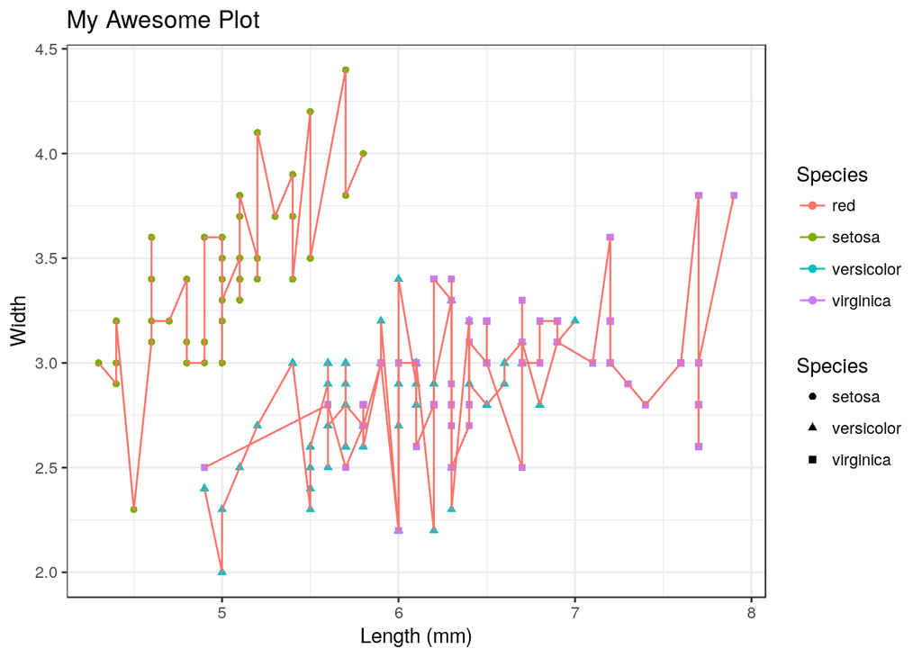

```r
p <- ggplot(iris, aes(x = Sepal.Length, y = Sepal.Width, colour = Species, shape = Species)) +
  geom_point() +
  geom_line(aes(colour = "red")) +
  ylab("Width") + xlab("Length (mm)") +
  ggtitle("My Awesome Plot") +
  theme_bw()

p
```

using ggsave() to save a plot

```r
ggsave(filename = '~/pretty_plot.png', plot = p, device = 'png')
```

using the last plot function to replot the last plot with no legend

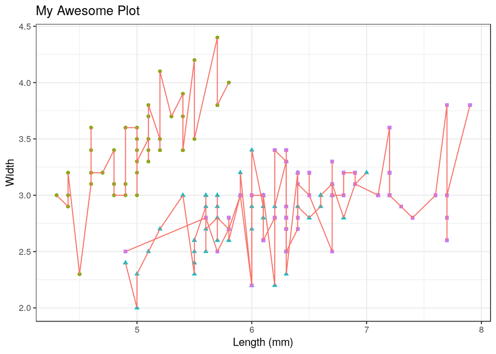

```r
last_plot() + theme(legend.position = 'none')
```

showing dplyr being combined with ggplot

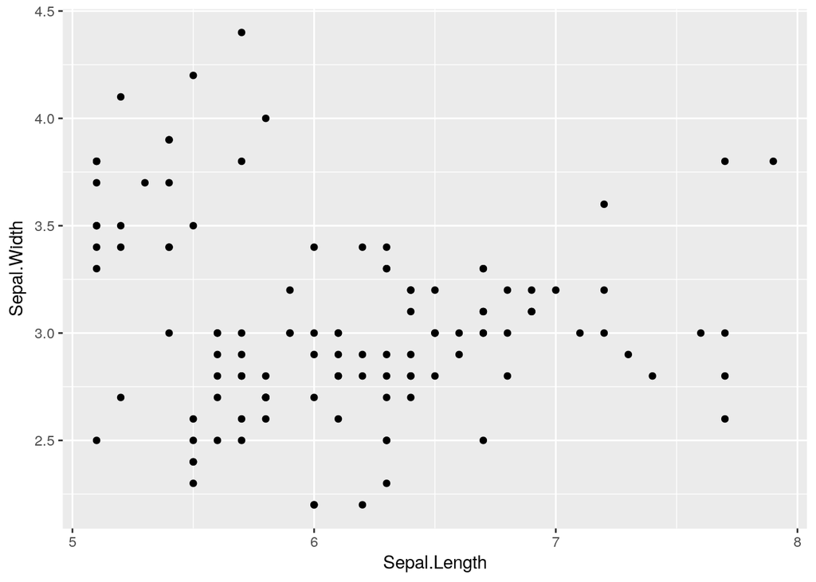

```r
iris %>%
  select(Sepal.Length, Sepal.Width, Species) %>%
  filter(Sepal.Length > 5) %>%
  ggplot(., aes(x = Sepal.Length, y =Sepal.Width)) + geom_point()
```

tidyr example attempt to collapse sepal.length and sepal.width into a grouping variable (dimension) and a data variable (mm)

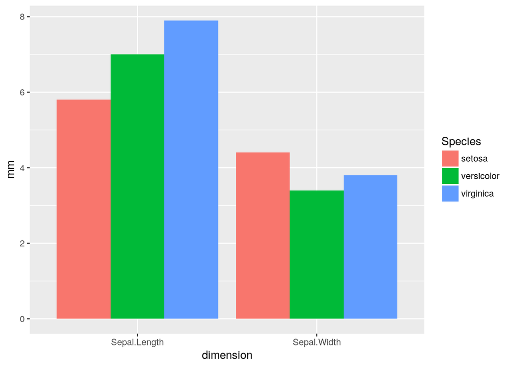

```r
iris %>%
  select(Species, Sepal.Length, Sepal.Width) %>%
  gather(.,"dimension", "mm", 2:3) %>% # gather is from tidyr
  ggplot(., aes(x = dimension, y = mm, fill = Species)) +
  geom_bar(stat = 'identity', position = 'dodge')
```

A recreation of the SWC loops lesson for plotting multiple datasets

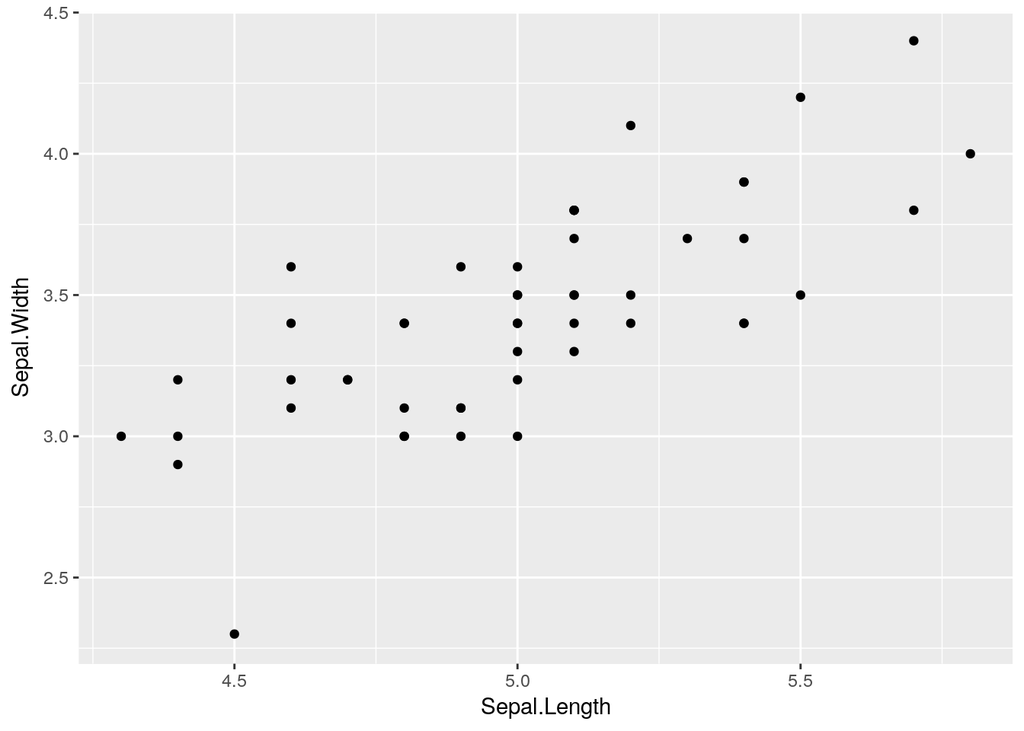

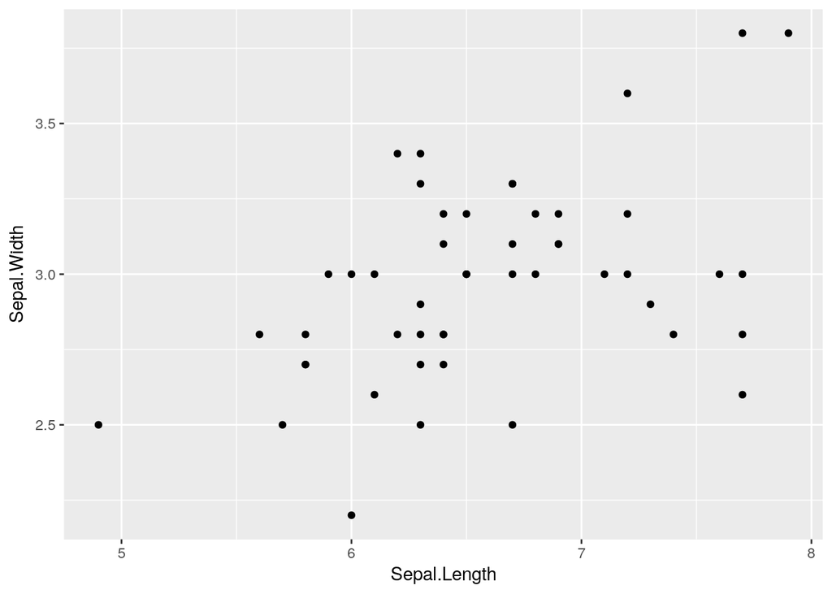

```r
# create the plotting function
plot_graphs <- function(df){
  p <- ggplot(df, aes(x = Sepal.Length, y = Sepal.Width)) + geom_point()
  return(p)
}

# create some example datasets
df1 <- iris %>% filter(Species == 'setosa')
df2 <- iris %>% filter(Species == 'virginica')
datasets <- list(df1, df2)

# plot using a loop
for(d in datasets){
  plot(plot_graphs(d))
}
```